# Convolutional Neural Networks

**Convolutional Neural Networks (CNNs)** are a class of deep neural networks specifically designed for processing structured grid-like data. They are designed to process visual data like images and videos, but they can also be used in sequential data applications.

They are especially good at recognizing patterns, detecting objects, and classifying images. Instead of treating an image as a simple set of numbers (pixels), CNNs automatically learn spatial features — meaning they understand shapes, edges, and textures—without needing manual feature selection.

CNNs leverage shared weights (kernels) and local connectivity, reducing the number of parameters compared to fully connected networks and enabling them to learn translation-invariant features.

If you think of how humans recognize objects, we don’t analyze every single pixel one by one. Instead, we look at **features** like edges, corners, and textures, and combine them to form a bigger picture. CNNs work in a similar way, breaking down an image into smaller parts and gradually learning what matters for a specific task.

[figure not shown]

### Convolution Preview

Before we break down the math, watch this short clip. It shows the core idea visually: a small **filter (kernel)** slides across an image, and at each stop its values are multiplied with the underlying pixels and summed into a single number. Repeat that across the whole image and you get a new **feature map** that highlights a particular pattern — exactly what a convolutional layer learns to do.

```python
%%HTML
<div style="text-align:center; margin:1em 0;">
<iframe src="https://www.facebook.com/plugins/video.php?height=624&href=https%3A%2F%2Fwww.facebook.com%2Freel%2F1211984404458134%2F&show_text=false&width=350&t=0" width="350" height="624" style="border:none;overflow:hidden" scrolling="no" frameborder="0" allowfullscreen="true" allow="autoplay; clipboard-write; encrypted-media; picture-in-picture; web-share" allowFullScreen="true"></iframe>
</div>
```

[interactive chart not shown]

### The Convolutional Layer

The **convolutional layer** is the foundation of a CNN. It applies filters (also called **kernels**) to the input image to detect important features, such as edges, textures, and patterns.

#### How Convolution Works

- A **filter (kernel)** is a small matrix (e.g., 3×3 or 5×5) that slides over the image.
- At each position, the filter performs an **element-wise multiplication** with the corresponding region of the image. (Essentially, the dot product.)
- The results are summed up to produce a **single value** in the output **feature map**.
- The filter moves across the entire image, creating a new representation of the image that highlights certain patterns.

#### Mathematical Formulation

Given an input image $ X $ and a filter $ W $, the convolution operation is:

$$ Y(i,j) = \sum_m \sum_n X(i+m, j+n) W(m,n) + b $$

where:

- $ Y(i,j) $ is the output feature map.
- $ W(m,n) $ is the convolution kernel (filter).
- $ b $ is the bias term.

#### Why Convolution Works

- Filters automatically learn to detect features during training.
- Multiple filters are used to extract different features from the same image.
- The convolution operation reduces the number of parameters compared to a fully connected layer, making CNNs more efficient for high-dimensional data.

[figure not shown]

#### Examples

First we set up a shared input image, a few kernels, and a plotting helper used by both the TensorFlow and PyTorch cells below.

```python
import numpy as np
import matplotlib.pyplot as plt

# -----------------------------------------------------------------------------
# A simple, recognizable 64x64 grayscale image. We draw a few shapes so the
# edges are obvious to the eye.
# -----------------------------------------------------------------------------
img = np.zeros((64, 64), dtype=np.float32)
img[12:52, 14:24] = 1.0                          # vertical bar    -> vertical edges
img[40:50, 14:50] = 1.0                          # horizontal bar  -> horizontal edges
yy, xx = np.mgrid[0:64, 0:64]
img[(yy - 22)**2 + (xx - 44)**2 < 11**2] = 1.0   # filled circle   -> curved edges

# -----------------------------------------------------------------------------
# Three classic 3x3 kernels. In a real CNN these weights are LEARNED during
# training -- here we set them by hand so we can SEE what convolution extracts.
# -----------------------------------------------------------------------------
kernels = {
    "Vertical edges":   [[-1, 0, 1], [-2, 0, 2], [-1, 0, 1]],   # Sobel-x
    "Horizontal edges": [[-1, -2, -1], [0, 0, 0], [1, 2, 1]],   # Sobel-y
    "Blur (smoothing)": (np.ones((3, 3)) / 9.0).tolist(),       # box blur
}

def show_feature_maps(original, feature_maps, names, suptitle=""):
    """Plot the original image next to each filter's feature map (before vs. after)."""
    fig, axes = plt.subplots(1, len(feature_maps) + 1, figsize=(16, 4))
    axes[0].imshow(original, cmap='gray')
    axes[0].set_title("Original image")
    for ax, fmap, name in zip(axes[1:], feature_maps, names):
        # Edge detectors produce signed values; show magnitude so both edges are visible.
        ax.imshow(np.abs(fmap), cmap='gray')
        ax.set_title(name)
    for ax in axes:
        ax.axis('off')
    if suptitle:
        fig.suptitle(suptitle)
    plt.tight_layout()
    plt.show()


def print_value_crop(arrays, names, r0=30, c0=11, size=8, gap="   "):
    """Show the actual pixel-value matrices behind a small patch of the images,
    printed SIDE BY SIDE.

    We crop the same 8x8 window (the left edge of the vertical bar) from the
    original image and each feature map, so students can read the numbers that
    produced the pictures above."""
    print(f"Pixel values for an {size}x{size} crop at rows {r0}-{r0+size-1}, "
          f"cols {c0}-{c0+size-1} (the left edge of the vertical bar):\n")
    blocks = []
    for arr, name in zip(arrays, names):
        sub = arr[r0:r0+size, c0:c0+size]
        # Original is 0/1; feature maps get 1 decimal so the blur's averaging shows.
        crop = sub.astype(int) if name == "Original" else np.round(sub, 1)
        body = np.array2string(crop, max_line_width=200).split("\n")
        width = max(len(name), max(len(line) for line in body))
        blocks.append([name.ljust(width)] + [line.ljust(width) for line in body])
    # Print the column headers and each matrix row next to one another.
    for row in zip(*blocks):
        print(gap.join(row))
```

#### TensorFlow/Keras

```
Input shape:  (1, 64, 64, 1)
Output shape: (1, 64, 64, 3)
```

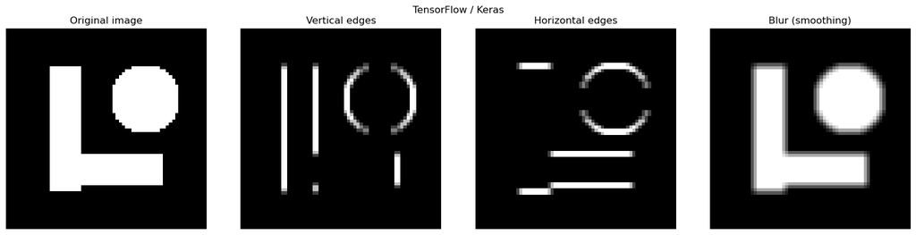

```
Pixel values for an 8x8 crop at rows 30-37, cols 11-18 (the left edge of the vertical bar):

Original              Vertical edges                Horizontal edges              Blur (smoothing)
[[0 0 0 1 1 1 1 1]    [[0. 0. 4. 4. 0. 0. 0. 0.]    [[0. 0. 0. 0. 0. 0. 0. 0.]    [[0.  0.  0.3 0.7 1.  1.  1.  1. ]
 [0 0 0 1 1 1 1 1]     [0. 0. 4. 4. 0. 0. 0. 0.]     [0. 0. 0. 0. 0. 0. 0. 0.]     [0.  0.  0.3 0.7 1.  1.  1.  1. ]
 [0 0 0 1 1 1 1 1]     [0. 0. 4. 4. 0. 0. 0. 0.]     [0. 0. 0. 0. 0. 0. 0. 0.]     [0.  0.  0.3 0.7 1.  1.  1.  1. ]
 [0 0 0 1 1 1 1 1]     [0. 0. 4. 4. 0. 0. 0. 0.]     [0. 0. 0. 0. 0. 0. 0. 0.]     [0.  0.  0.3 0.7 1.  1.  1.  1. ]
 [0 0 0 1 1 1 1 1]     [0. 0. 4. 4. 0. 0. 0. 0.]     [0. 0. 0. 0. 0. 0. 0. 0.]     [0.  0.  0.3 0.7 1.  1.  1.  1. ]
 [0 0 0 1 1 1 1 1]     [0. 0. 4. 4. 0. 0. 0. 0.]     [0. 0. 0. 0. 0. 0. 0. 0.]     [0.  0.  0.3 0.7 1.  1.  1.  1. ]
 [0 0 0 1 1 1 1 1]     [0. 0. 4. 4. 0. 0. 0. 0.]     [0. 0. 0. 0. 0. 0. 0. 0.]     [0.  0.  0.3 0.7 1.  1.  1.  1. ]
 [0 0 0 1 1 1 1 1]]    [0. 0. 4. 4. 0. 0. 0. 0.]]    [0. 0. 0. 0. 0. 0. 0. 0.]]    [0.  0.  0.3 0.7 1.  1.  1.  1. ]]
```

```python
import tensorflow as tf
from keras.layers import Conv2D

# TensorFlow expects (batch, height, width, channels).
image = img.reshape(1, 64, 64, 1)

# A Conv2D layer with one filter per kernel. padding='same' keeps the output the
# same size as the input so the before/after images line up.
conv_layer = Conv2D(filters=len(kernels), kernel_size=(3, 3), strides=1,
                    padding='same', activation=None, use_bias=False)
conv_layer.build(input_shape=(None, 64, 64, 1))

# Load our hand-made kernels. Conv2D weight shape is (kernel_h, kernel_w, in_ch, out_ch).
W = np.zeros((3, 3, 1, len(kernels)), dtype=np.float32)
for i, k in enumerate(kernels.values()):
    W[:, :, 0, i] = np.array(k, dtype=np.float32)
conv_layer.set_weights([W])

# Apply the convolution.
output = conv_layer(image)
print("Input shape: ", image.shape)     # (1, 64, 64, 1)
print("Output shape:", output.shape)    # (1, 64, 64, 3) -> one feature map per filter

feature_maps = [output[0, :, :, i].numpy() for i in range(len(kernels))]
show_feature_maps(img, feature_maps, kernels.keys(), "TensorFlow / Keras")

# Show the numbers under the hood for a readable crop of the images above.
print_value_crop([img] + feature_maps, ["Original"] + list(kernels.keys()))
```

#### PyTorch

```python
import torch
import torch.nn as nn

# PyTorch expects (batch, channels, height, width) -- channels come first.
image = torch.tensor(img).reshape(1, 1, 64, 64)

# A Conv2d layer with one filter per kernel. padding=1 keeps the output 64x64.
conv_layer = nn.Conv2d(in_channels=1, out_channels=len(kernels), kernel_size=3,
                       stride=1, padding=1, bias=False)

# Load our hand-made kernels. Conv2d weight shape is (out_ch, in_ch, kernel_h, kernel_w).
W = torch.zeros(len(kernels), 1, 3, 3)
for i, k in enumerate(kernels.values()):
    W[i, 0] = torch.tensor(k, dtype=torch.float32)
with torch.no_grad():
    conv_layer.weight.copy_(W)

# Apply the convolution.
with torch.no_grad():
    output = conv_layer(image)
print("Input shape: ", tuple(image.shape))     # (1, 1, 64, 64)
print("Output shape:", tuple(output.shape))    # (1, 3, 64, 64) -> one feature map per filter

feature_maps = [output[0, i].numpy() for i in range(len(kernels))]
show_feature_maps(img, feature_maps, kernels.keys(), "PyTorch")

# Show the numbers under the hood for a readable crop of the images above.
print_value_crop([img] + feature_maps, ["Original"] + list(kernels.keys()))
```

### Stride And Padding

Two important parameters that affect how convolution is performed are **stride** and **padding**. These parameters impact the size of the output feature map and how much information is retained from the input.

[figure not shown]

#### Stride

The stride defines how much the filter moves across the image in each step during convolution.

- A smaller stride (e.g., 1) means the filter moves pixel by pixel, capturing fine-grained details.
- A larger stride (e.g., 2 or more) skips pixels, making the output smaller but reducing computational cost.

#### Padding

Padding is the process of adding extra pixels (usually zeros) around the edges of the input image before applying convolution. This controls how much of the image is preserved in the output.

There are two common types of padding used in CNNs:

**Valid Padding ("No Padding")**

- No extra pixels are added.
- The output feature map is smaller than the input.
- Ensures that no redundant pixels are included in calculations.
- Formula for output size:

$$ \frac{(N - F)}{S} + 1 $$

where:

- $ N $ = input size
- $ F $ = filter size
- $ S $ = stride

**Same Padding ("Zero Padding")**

- Extra zeros are added so that the output has the same spatial dimensions as the input.
- Ensures that edge information is **not lost**.
- Used when we want to keep the feature map size unchanged.
- Formula for output size:

$$ \frac{N}{S} $$

### Activation Function

After the convolution operation, CNNs apply an **activation function** to introduce non-linearity. Without this step, the CNN would behave like a simple linear model, limiting its ability to capture complex patterns. With this step, the activation function acts as a filter that keeps only useful information and discards irrelevant (negative) values.

#### ReLU (Rectified Linear Unit)

The most commonly used activation function in CNNs is **ReLU**, which is defined as:

$$ f(x) = \max(0, x) $$

#### Why ReLU?

- It **removes negative values**, ensuring only relevant features are passed forward.
- It helps with the **vanishing gradient problem**, where gradients become too small in deep networks, slowing learning.
- It makes training faster and improves convergence.

#### TensorFlow/Keras

```python
from keras.layers import Activation
import numpy as np

# ReLU keeps positive values and turns negatives into 0.
x = np.array([-3, -1, 0, 2, 5], dtype=np.float32)
print("Input:", x)
print("ReLU: ", Activation('relu')(x).numpy())
```

```
Input: [-3. -1.  0.  2.  5.]
ReLU:  [0. 0. 0. 2. 5.]
```

#### PyTorch

```python
import torch
import torch.nn as nn

x = torch.tensor([-3., -1., 0., 2., 5.])
print("Input:", x.numpy())
print("ReLU: ", nn.ReLU()(x).numpy())
```

### Pooling Layer

Pooling layers work to **reduce the size of feature maps** while retaining important information. This makes the network more computationally efficient and less sensitive to small variations or distortions in the image. Pooling is like taking a summary — max pooling picks the **most prominent** feature, while average pooling gives an **overall impression**.

#### Types of Pooling

1. **Max Pooling**: Takes the **maximum** value from each pooling window, esentially keeping the most dominant feature in each region.
   - Example: From a 2×2 window **[1, 3, 5, 2]**, max pooling keeps **5**.
2. **Average Pooling**: Computes the **average** of values in each pooling window, and essentially keeps more of the overall information.
   - Example: From **[1, 3, 5, 2]**, average pooling keeps **(1+3+5+2)/4 = 2.75**.

[figure not shown]

#### Examples

First we build the feature map we'll pool and a small plotting helper, then apply pooling in each framework below.

```python
from numpy.lib.stride_tricks import sliding_window_view

# Pooling acts on FEATURE MAPS, so we first make one ("vertical edges") from our
# image using a plain NumPy convolution (framework-agnostic), then pool it below.
k = np.array(kernels["Vertical edges"], dtype=np.float32)
windows = sliding_window_view(np.pad(img, 1), (3, 3))     # one 3x3 patch per pixel
feature_map = np.abs(np.einsum('ijkl,kl->ij', windows, k)).astype(np.float32)  # (64, 64)

def show_pooling(original, max_pooled, avg_pooled):
    """Plot the feature map before pooling, and after max vs. average pooling."""
    panels = [original, max_pooled, avg_pooled]
    titles = [f"Feature map {original.shape}",
              f"Max pooling {max_pooled.shape}",
              f"Average pooling {avg_pooled.shape}"]
    vmax = original.max()   # shared color scale so max-vs-average dimming is visible
    fig, axes = plt.subplots(1, 3, figsize=(13, 4))
    for ax, p, t in zip(axes, panels, titles):
        ax.imshow(p, cmap='gray', vmin=0, vmax=vmax)
        ax.set_title(t)
        ax.axis('off')
    plt.tight_layout()
    plt.show()


def print_pool_crop(original, max_pooled, avg_pooled, r0=30, c0=10, size=8, gap="   "):
    """Show the pixel-value matrices behind a small patch before/after pooling,
    printed SIDE BY SIDE.

    The before-crop is size x size; the after-crops are half that, since 2x2
    pooling with stride 2 halves the grid (shorter blocks are padded to line up)."""
    h = size // 2
    pr0, pc0 = r0 // 2, c0 // 2
    panels = [
        (f"Feature map (before) {size}x{size}", np.round(original[r0:r0+size, c0:c0+size]).astype(int)),
        (f"Max pooling (after) {h}x{h}",        np.round(max_pooled[pr0:pr0+h, pc0:pc0+h]).astype(int)),
        (f"Average pooling (after) {h}x{h}",    np.round(avg_pooled[pr0:pr0+h, pc0:pc0+h], 1)),
    ]
    print(f"Crop at rows {r0}-{r0+size-1}, cols {c0}-{c0+size-1} "
          f"(2x2 pooling halves the grid):\n")
    blocks = []
    for name, arr in panels:
        body = np.array2string(arr, max_line_width=200).split("\n")
        width = max(len(name), max(len(line) for line in body))
        blocks.append([name.ljust(width)] + [line.ljust(width) for line in body])
    nlines = max(len(b) for b in blocks)
    for b in blocks:                                   # pad the shorter 4x4 blocks
        b += [" " * len(b[0])] * (nlines - len(b))
    for row in zip(*blocks):
        print(gap.join(row))
```

#### TensorFlow/Keras

```
Feature map shape: (1, 64, 64, 1)
After max pooling: (1, 32, 32, 1)
After avg pooling: (1, 32, 32, 1)
```

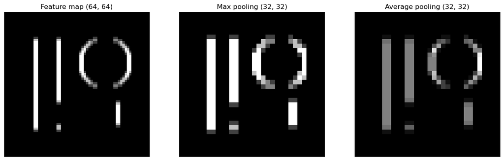

```
Crop at rows 30-37, cols 10-17 (2x2 pooling halves the grid):

Feature map (before) 8x8   Max pooling (after) 4x4   Average pooling (after) 4x4
[[0 0 0 4 4 0 0 0]         [[0 4 4 0]                [[0. 2. 2. 0.]
 [0 0 0 4 4 0 0 0]          [0 4 4 0]                 [0. 2. 2. 0.]
 [0 0 0 4 4 0 0 0]          [0 4 4 0]                 [0. 2. 2. 0.]
 [0 0 0 4 4 0 0 0]          [0 4 4 0]]                [0. 2. 2. 0.]]
 [0 0 0 4 4 0 0 0]
 [0 0 0 4 4 0 0 0]
 [0 0 0 4 4 0 0 0]
 [0 0 0 4 4 0 0 0]]
```

```python
from keras.layers import MaxPooling2D, AveragePooling2D

# TensorFlow expects (batch, height, width, channels).
x = feature_map.reshape(1, 64, 64, 1)

# 2x2 pooling, stride 2: each 2x2 window becomes ONE value -> the map is halved.
max_pooled = MaxPooling2D(pool_size=(2, 2), strides=2)(x)
avg_pooled = AveragePooling2D(pool_size=(2, 2), strides=2)(x)

print("Feature map shape:", x.shape)            # (1, 64, 64, 1)
print("After max pooling:", max_pooled.shape)   # (1, 32, 32, 1) -> half the size
print("After avg pooling:", avg_pooled.shape)   # (1, 32, 32, 1)

show_pooling(feature_map, max_pooled[0, :, :, 0].numpy(), avg_pooled[0, :, :, 0].numpy())

# Show the numbers under the hood for a readable crop, before vs. after pooling.
print_pool_crop(feature_map, max_pooled[0, :, :, 0].numpy(), avg_pooled[0, :, :, 0].numpy())
```

#### PyTorch

```python
# PyTorch expects (batch, channels, height, width).
x = torch.tensor(feature_map).reshape(1, 1, 64, 64)

# 2x2 pooling, stride 2: each 2x2 window becomes ONE value -> the map is halved.
max_pooled = nn.MaxPool2d(kernel_size=2, stride=2)(x)
avg_pooled = nn.AvgPool2d(kernel_size=2, stride=2)(x)

print("Feature map shape:", tuple(x.shape))          # (1, 1, 64, 64)
print("After max pooling:", tuple(max_pooled.shape)) # (1, 1, 32, 32) -> half the size
print("After avg pooling:", tuple(avg_pooled.shape)) # (1, 1, 32, 32)

show_pooling(feature_map, max_pooled[0, 0].numpy(), avg_pooled[0, 0].numpy())

# Show the numbers under the hood for a readable crop, before vs. after pooling.
print_pool_crop(feature_map, max_pooled[0, 0].numpy(), avg_pooled[0, 0].numpy())
```

### Fully Connected Layer

After convolutional and pooling layers have extracted features, the **fully connected layer** translates them into a final prediction.

#### How It Works

- The output feature maps from previous layers are **flattened** into a 1D vector.
- This vector is passed through one or more **fully connected layers**, where each neuron is connected to every neuron in the previous layer.
- These layers learn to associate extracted features with specific **labels or categories**.

#### Mathematical Representation

A fully connected layer applies:

$$ y = W x + b $$

where:

- $ W $ represents the learned **weights**,
- $ x $ is the **input feature vector**,
- $ b $ is the **bias term**.

#### TensorFlow/Keras

```python
from keras.layers import Flatten, Dense
import numpy as np

# Pretend these are pooled feature maps: 1 sample, 14x14, 32 channels.
pooled = np.random.rand(1, 14, 14, 32).astype(np.float32)

flattened = Flatten()(pooled)
dense_output = Dense(128, activation='relu')(flattened)
print("Flattened: ", flattened.shape)      # (1, 6272) = 14*14*32
print("After Dense:", dense_output.shape)   # (1, 128)
```

```
Flattened:  (1, 6272)
After Dense: (1, 128)
```

#### PyTorch

```python
import torch
import torch.nn as nn

pooled = torch.rand(1, 32, 14, 14)
flattened = nn.Flatten()(pooled)
dense_output = nn.Linear(flattened.shape[1], 128)(flattened)
print("Flattened: ", tuple(flattened.shape))     # (1, 6272)
print("After Dense:", tuple(dense_output.shape))  # (1, 128)
```

### Softmax Layer

The final layer in a CNN (for classification tasks) is typically the **Softmax layer**. This layer converts raw output scores (logits) into **probabilities** for each class.

#### Softmax Formula

$$ \sigma(z_i) = \frac{e^{z_i}}{\sum_{j} e^{z_j}} $$

where:

- $ z_i $ is the score for class $ i $.
- The denominator sums up the exponentiated scores across all classes.

#### Why Use Softmax?

- It ensures the outputs sum to **1**, making them interpretable as probabilities.
- The class with the **highest probability** is selected as the CNN's final prediction.

#### TensorFlow/Keras

```python
from keras.layers import Softmax
import numpy as np

# Raw scores for 10 classes -> softmax turns them into probabilities that sum to 1.
logits = np.array([[2.0, 1.0, 0.1, 3.0, 0.5, 1.5, 0.2, 2.2, 0.8, 1.1]], dtype=np.float32)
probs = Softmax()(logits).numpy()
print("Probabilities:", probs.round(3))
print("Sum:", probs.sum())
```

```
Probabilities: [[0.14  0.051 0.021 0.38  0.031 0.085 0.023 0.171 0.042 0.057]]
Sum: 1.0
```

#### PyTorch

```python
import torch
import torch.nn as nn

logits = torch.tensor([[2.0, 1.0, 0.1, 3.0, 0.5, 1.5, 0.2, 2.2, 0.8, 1.1]])
probs = nn.Softmax(dim=1)(logits)
print("Probabilities:", probs.numpy().round(3))
print("Sum:", float(probs.sum()))
```

### Putting It All Together

Now we assemble the layers from the sections above into a single model.

#### TensorFlow/ Keras

```python
from tensorflow.keras.models import Sequential

model = Sequential([
    Conv2D(32, (3,3), activation='relu', padding='same', input_shape=(28,28,1)),
    MaxPooling2D(2,2),
    Flatten(),
    Dense(128, activation='relu'),
    Dense(10, activation='softmax')  # Output layer with 10 classes
])

model.summary()
```

```
Model: "sequential_1"
```

```
┏━━━━━━━━━━━━━━━━━━━━━━━━━━━━━━━━━┳━━━━━━━━━━━━━━━━━━━━━━━━┳━━━━━━━━━━━━━━━┓
┃ Layer (type)                    ┃ Output Shape           ┃       Param # ┃
┡━━━━━━━━━━━━━━━━━━━━━━━━━━━━━━━━━╇━━━━━━━━━━━━━━━━━━━━━━━━╇━━━━━━━━━━━━━━━┩
│ conv2d_6 (Conv2D)               │ (None, 28, 28, 32)     │           320 │
├─────────────────────────────────┼────────────────────────┼───────────────┤
│ max_pooling2d_7 (MaxPooling2D)  │ (None, 14, 14, 32)     │             0 │
├─────────────────────────────────┼────────────────────────┼───────────────┤
│ flatten_2 (Flatten)             │ (None, 6272)           │             0 │
├─────────────────────────────────┼────────────────────────┼───────────────┤
│ dense_3 (Dense)                 │ (None, 128)            │       802,944 │
├─────────────────────────────────┼────────────────────────┼───────────────┤
│ dense_4 (Dense)                 │ (None, 10)             │         1,290 │
└─────────────────────────────────┴────────────────────────┴───────────────┘
```

```
 Total params: 804,554 (3.07 MB)
```

```
 Trainable params: 804,554 (3.07 MB)
```

```
 Non-trainable params: 0 (0.00 B)
```

#### PyTorch

```python
class SimpleCNN(nn.Module):
    def __init__(self):
        super(SimpleCNN, self).__init__()
        self.conv1 = nn.Conv2d(in_channels=1, out_channels=32, kernel_size=3, padding=1)
        self.relu = nn.ReLU()
        self.pool = nn.MaxPool2d(2,2)
        self.flatten = nn.Flatten()
        self.fc1 = nn.Linear(32 * 14 * 14, 128)  # Adjusted for image size
        self.fc2 = nn.Linear(128, 10)
        self.softmax = nn.Softmax(dim=1)

    def forward(self, x):
        x = self.conv1(x)
        x = self.relu(x)
        x = self.pool(x)
        x = self.flatten(x)
        x = self.fc1(x)
        x = self.relu(x)
        x = self.fc2(x)
        x = self.softmax(x)
        return x

# Create model and print architecture
model = SimpleCNN()
print(model)
```

### Prepare The Data

```python
!pip install seaborn
```

```python
# Import necessary libraries
import tensorflow as tf
import matplotlib.pyplot as plt
import seaborn as sns
import numpy as np
from keras import datasets, layers, models
from sklearn.metrics import confusion_matrix, classification_report

# Load the Fashion MNIST dataset
(train_images, train_labels), (test_images, test_labels) = datasets.fashion_mnist.load_data()

# Normalize the images to [0, 1] range for better training stability
train_images, test_images = train_images / 255.0, test_images / 255.0

# Reshape the images to add a channel dimension (28x28 grayscale images → 28x28x1)
train_images = train_images.reshape((train_images.shape[0], 28, 28, 1))
test_images = test_images.reshape((test_images.shape[0], 28, 28, 1))

# Define the class labels for reference
class_names = ['T-shirt/top', 'Trouser', 'Pullover', 'Dress', 'Coat',
               'Sandal', 'Shirt', 'Sneaker', 'Bag', 'Ankle boot']
```

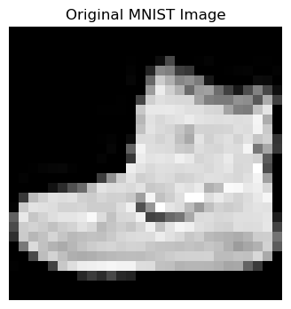

```python
# Select a single image
image = train_images[0]  # First image in the dataset

# Display the original image
plt.figure(figsize=(4,4))
plt.imshow(image, cmap='gray')
plt.title("Original MNIST Image")
plt.axis('off')
plt.show()
```

### Build The CNN Model

```python
# Build the CNN Model
model = models.Sequential([
    layers.Conv2D(32, (3,3), activation='relu', input_shape=(28, 28, 1)),
    layers.MaxPooling2D((2,2)),

    layers.Conv2D(64, (3,3), activation='relu'),
    layers.MaxPooling2D((2,2)),

    layers.Conv2D(128, (3,3), activation='relu'),

    layers.Flatten(),
    layers.Dense(128, activation='relu'),
    layers.Dense(10, activation='softmax')  # Output layer for 10 classes
])

# Compile the model
model.compile(optimizer='adam',
              loss='sparse_categorical_crossentropy',
              metrics=['accuracy'])
```

```python
# Train the model
history = model.fit(train_images, train_labels, epochs=10,
                    validation_data=(test_images, test_labels))

# Evaluate model performance
test_loss, test_acc = model.evaluate(test_images, test_labels)
print("\nTest accuracy:", test_acc)
```

```
1875/1875 ━━━━━━━━━━━━━━━━━━━━ 14s 7ms/step - accuracy: 0.8277 - loss: 0.4674 - val_accuracy: 0.8759 - val_loss: 0.3461
1875/1875 ━━━━━━━━━━━━━━━━━━━━ 14s 7ms/step - accuracy: 0.8893 - loss: 0.3043 - val_accuracy: 0.8866 - val_loss: 0.3092
1875/1875 ━━━━━━━━━━━━━━━━━━━━ 13s 7ms/step - accuracy: 0.9046 - loss: 0.2603 - val_accuracy: 0.9024 - val_loss: 0.2675
1875/1875 ━━━━━━━━━━━━━━━━━━━━ 14s 7ms/step - accuracy: 0.9146 - loss: 0.2309 - val_accuracy: 0.9054 - val_loss: 0.2660
1875/1875 ━━━━━━━━━━━━━━━━━━━━ 13s 7ms/step - accuracy: 0.9246 - loss: 0.2028 - val_accuracy: 0.9080 - val_loss: 0.2584
1875/1875 ━━━━━━━━━━━━━━━━━━━━ 13s 7ms/step - accuracy: 0.9326 - loss: 0.1803 - val_accuracy: 0.9095 - val_loss: 0.2545
1875/1875 ━━━━━━━━━━━━━━━━━━━━ 14s 7ms/step - accuracy: 0.9407 - loss: 0.1583 - val_accuracy: 0.9097 - val_loss: 0.2758
1875/1875 ━━━━━━━━━━━━━━━━━━━━ 15s 8ms/step - accuracy: 0.9471 - loss: 0.1422 - val_accuracy: 0.9087 - val_loss: 0.2858
1875/1875 ━━━━━━━━━━━━━━━━━━━━ 14s 8ms/step - accuracy: 0.9529 - loss: 0.1272 - val_accuracy: 0.9123 - val_loss: 0.2823
1875/1875 ━━━━━━━━━━━━━━━━━━━━ 14s 8ms/step - accuracy: 0.9578 - loss: 0.1119 - val_accuracy: 0.9100 - val_loss: 0.3240
313/313 ━━━━━━━━━━━━━━━━━━━━ 1s 2ms/step - accuracy: 0.9100 - loss: 0.3240

Test accuracy: 0.9100000262260437
```

### Evaluate Accuracy And Loss

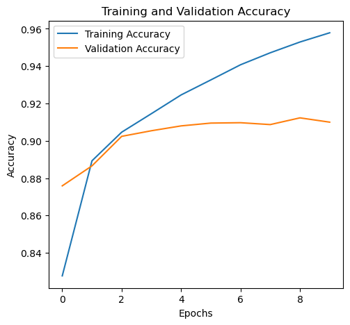

```python
# Plot training accuracy and validation accuracy
plt.figure(figsize=(12, 5))

# Accuracy plot
plt.subplot(1, 2, 1)
plt.plot(history.history['accuracy'], label='Training Accuracy')
plt.plot(history.history['val_accuracy'], label='Validation Accuracy')
plt.xlabel('Epochs')
plt.ylabel('Accuracy')
plt.title('Training and Validation Accuracy')
plt.legend()

plt.show()
```

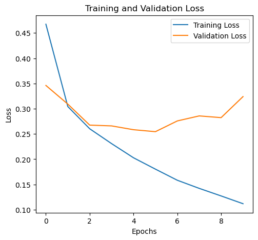

```python
# Plot training loss and validation loss
plt.figure(figsize=(12, 5))

# Loss plot
plt.subplot(1, 2, 2)
plt.plot(history.history['loss'], label='Training Loss')
plt.plot(history.history['val_loss'], label='Validation Loss')
plt.xlabel('Epochs')
plt.ylabel('Loss')
plt.title('Training and Validation Loss')
plt.legend()

plt.show()
```

### Evaluate Confusion Matrix

```
313/313 ━━━━━━━━━━━━━━━━━━━━ 1s 2ms/step
```

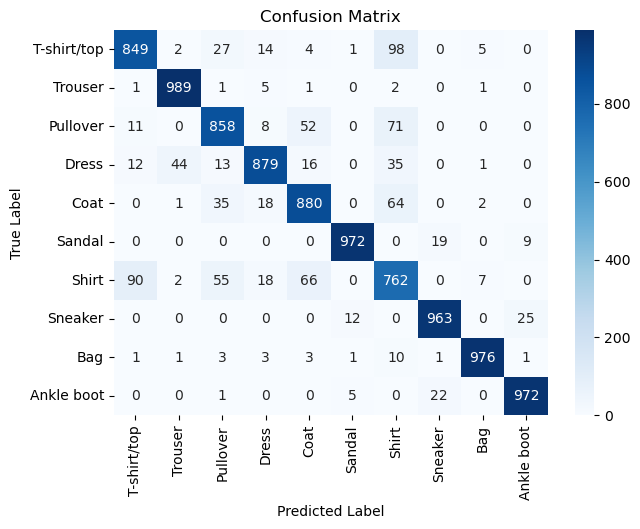

```python
# Get model predictions
predictions = model.predict(test_images)
predicted_labels = np.argmax(predictions, axis=1)

# Generate confusion matrix
conf_matrix = confusion_matrix(test_labels, predicted_labels)

# Plot confusion matrix
plt.figure(figsize=(7, 5))
sns.heatmap(conf_matrix, annot=True, fmt='d', cmap='Blues',
            xticklabels=class_names, yticklabels=class_names)
plt.xlabel('Predicted Label')
plt.ylabel('True Label')
plt.title('Confusion Matrix')
plt.show()
```

```python
# Display classification report
print("\nClassification Report:\n", classification_report(test_labels, predicted_labels, target_names=class_names))
```

```
Classification Report:
               precision    recall  f1-score   support

 T-shirt/top       0.88      0.85      0.86      1000
     Trouser       0.95      0.99      0.97      1000
    Pullover       0.86      0.86      0.86      1000
       Dress       0.93      0.88      0.90      1000
        Coat       0.86      0.88      0.87      1000
      Sandal       0.98      0.97      0.98      1000
       Shirt       0.73      0.76      0.75      1000
     Sneaker       0.96      0.96      0.96      1000
         Bag       0.98      0.98      0.98      1000
  Ankle boot       0.97      0.97      0.97      1000

    accuracy                           0.91     10000
   macro avg       0.91      0.91      0.91     10000
weighted avg       0.91      0.91      0.91     10000
```

## Real-World CNN Example: Detecting Malaria from Blood-Smear Images

The MNIST/Fashion-MNIST example above used a clean, pre-processed benchmark dataset. **Real data is rarely so tidy.** Here we apply the *same CNN tools* to an actual medical-imaging problem: detecting the malaria parasite in microscope images of blood cells.

The dataset comes from the U.S. **National Institutes of Health (NIH)** and contains **27,558 cell images** segmented from thin blood smears, each labeled **parasitized** (infected) or **uninfected**. Automating this matters because manual microscopy is slow, needs trained experts, and is error-prone in exactly the low-resource regions where malaria is most common.

Notice what makes this harder than MNIST:

- the images are **full color** and come in **many different sizes** (so we must resize them to a common shape),
- there is only **one data split**, so we carve out our own train / validation / test sets, and
- the visual cue (a small parasite inside the cell) is **subtle** compared to a bold handwritten digit.

> **Heads-up:** the first run downloads ~340 MB (cached afterward). We use a lightweight subset and a few epochs so it runs anywhere — set `USE_FULL = True` to train on the entire dataset.

### Prepare The Data

```python
# Install tensorflow-datasets INTO THE KERNEL'S environment.
# Use %pip (the magic), NOT !pip -- !pip can install into a different Python
# than the notebook kernel, which causes "No module named 'tensorflow_datasets'".
# importlib_resources is a sub-dependency that pip doesn't always pull in on
# Python 3.11+ (tfds/etils import it lazily), so we install it explicitly.
%pip install -q tensorflow-datasets importlib_resources
```

```python
# Import necessary libraries
import tensorflow as tf
import tensorflow_datasets as tfds
import matplotlib.pyplot as plt
import seaborn as sns
import numpy as np
from keras import layers, models
from sklearn.metrics import confusion_matrix, classification_report

# ---- Lightweight-but-real config (bump these to train on more data / longer) ----
IMG_SIZE   = 64      # real images vary in size -> we resize them all to 64x64
EPOCHS     = 5
BATCH_SIZE = 32
USE_FULL   = False   # False = small subset (fast); True = full ~27,558-image dataset

# The malaria dataset ships as ONE 'train' split of 27,558 cell images. We slice
# it into disjoint train/validation/test sets (80% / 10% / 10%).
(train_raw, val_raw, test_raw), ds_info = tfds.load(
    'malaria',
    split=['train[:80%]', 'train[80%:90%]', 'train[90%:]'],
    as_supervised=True, with_info=True)

class_names = ds_info.features['label'].names
print("Classes:", class_names)
print("Total images available:", ds_info.splits['train'].num_examples)

# For a fast run, use a small subset of each split.
if not USE_FULL:
    train_raw = train_raw.take(4800)
    val_raw   = val_raw.take(600)
    test_raw  = test_raw.take(600)

# Resize every image to a fixed size and scale pixels to [0, 1]. This resizing
# step is essential here (unlike MNIST) because the raw images differ in size.
AUTOTUNE = tf.data.AUTOTUNE
def preprocess(image, label):
    image = tf.image.resize(image, (IMG_SIZE, IMG_SIZE)) / 255.0
    return image, label

train_ds = train_raw.map(preprocess, num_parallel_calls=AUTOTUNE).shuffle(1000).batch(BATCH_SIZE).prefetch(AUTOTUNE)
val_ds   = val_raw.map(preprocess, num_parallel_calls=AUTOTUNE).batch(BATCH_SIZE).prefetch(AUTOTUNE)
test_ds  = test_raw.map(preprocess, num_parallel_calls=AUTOTUNE).batch(BATCH_SIZE).prefetch(AUTOTUNE)

print("Image size:", IMG_SIZE, "| Using full dataset:", USE_FULL)
```

```
Classes: ['parasitized', 'uninfected']
Total images available: 27558
Image size: 64 | Using full dataset: False
```

[output not shown]

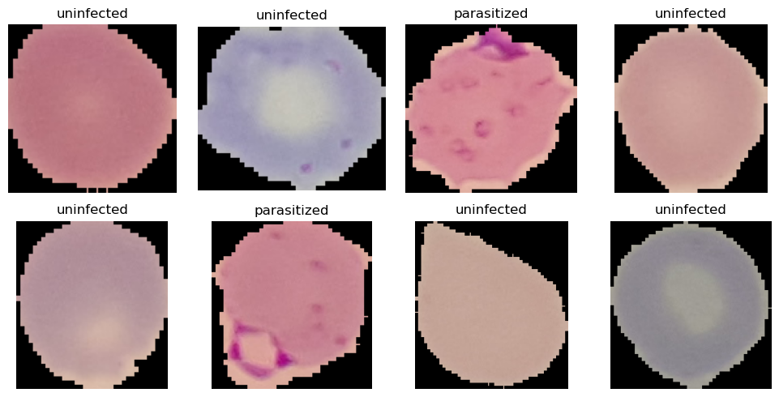

```python
# Look at a few REAL cells. Parasitized cells usually contain small purple/violet
# spots (the parasite); uninfected cells look clean.
plt.figure(figsize=(10, 5))
for i, (image, label) in enumerate(train_raw.take(8)):
    plt.subplot(2, 4, i + 1)
    plt.imshow(image.numpy())                 # original image, in its true colors
    plt.title(class_names[int(label)])
    plt.axis('off')
plt.tight_layout()
plt.show()
```

### Build The CNN Model

```python
# A from-scratch CNN -- the SAME building blocks as the MNIST model, adapted for
# 64x64 COLOR images and a BINARY (2-class) decision.
model = models.Sequential([
    layers.Conv2D(32, (3,3), activation='relu', input_shape=(IMG_SIZE, IMG_SIZE, 3)),
    layers.MaxPooling2D((2,2)),

    layers.Conv2D(64, (3,3), activation='relu'),
    layers.MaxPooling2D((2,2)),

    layers.Conv2D(128, (3,3), activation='relu'),
    layers.MaxPooling2D((2,2)),

    layers.Flatten(),
    layers.Dense(128, activation='relu'),
    layers.Dropout(0.5),                      # regularization -- helps on messy real data
    layers.Dense(1, activation='sigmoid')     # single output: probability of "parasitized"
])

model.compile(optimizer='adam',
              loss='binary_crossentropy',
              metrics=['accuracy'])
model.summary()
```

```
Model: "sequential"
```

```
┏━━━━━━━━━━━━━━━━━━━━━━━━━━━━━━━━━┳━━━━━━━━━━━━━━━━━━━━━━━━┳━━━━━━━━━━━━━━━┓
┃ Layer (type)                    ┃ Output Shape           ┃       Param # ┃
┡━━━━━━━━━━━━━━━━━━━━━━━━━━━━━━━━━╇━━━━━━━━━━━━━━━━━━━━━━━━╇━━━━━━━━━━━━━━━┩
│ conv2d (Conv2D)                 │ (None, 62, 62, 32)     │           896 │
├─────────────────────────────────┼────────────────────────┼───────────────┤
│ max_pooling2d (MaxPooling2D)    │ (None, 31, 31, 32)     │             0 │
├─────────────────────────────────┼────────────────────────┼───────────────┤
│ conv2d_1 (Conv2D)               │ (None, 29, 29, 64)     │        18,496 │
├─────────────────────────────────┼────────────────────────┼───────────────┤
│ max_pooling2d_1 (MaxPooling2D)  │ (None, 14, 14, 64)     │             0 │
├─────────────────────────────────┼────────────────────────┼───────────────┤
│ conv2d_2 (Conv2D)               │ (None, 12, 12, 128)    │        73,856 │
├─────────────────────────────────┼────────────────────────┼───────────────┤
│ max_pooling2d_2 (MaxPooling2D)  │ (None, 6, 6, 128)      │             0 │
├─────────────────────────────────┼────────────────────────┼───────────────┤
│ flatten (Flatten)               │ (None, 4608)           │             0 │
├─────────────────────────────────┼────────────────────────┼───────────────┤
│ dense (Dense)                   │ (None, 128)            │       589,952 │
├─────────────────────────────────┼────────────────────────┼───────────────┤
│ dropout (Dropout)               │ (None, 128)            │             0 │
├─────────────────────────────────┼────────────────────────┼───────────────┤
│ dense_1 (Dense)                 │ (None, 1)              │           129 │
└─────────────────────────────────┴────────────────────────┴───────────────┘
```

```
 Total params: 683,329 (2.61 MB)
```

```
 Trainable params: 683,329 (2.61 MB)
```

```
 Non-trainable params: 0 (0.00 B)
```

```python
# Train the model
history = model.fit(train_ds, validation_data=val_ds, epochs=EPOCHS)

# Evaluate on the held-out test set
test_loss, test_acc = model.evaluate(test_ds)
print("\nTest accuracy:", test_acc)
```

```
150/150 ━━━━━━━━━━━━━━━━━━━━ 6s 32ms/step - accuracy: 0.6190 - loss: 0.6454 - val_accuracy: 0.7717 - val_loss: 0.5400
150/150 ━━━━━━━━━━━━━━━━━━━━ 5s 32ms/step - accuracy: 0.8715 - loss: 0.3358 - val_accuracy: 0.9033 - val_loss: 0.2321
150/150 ━━━━━━━━━━━━━━━━━━━━ 5s 32ms/step - accuracy: 0.9454 - loss: 0.1719 - val_accuracy: 0.9517 - val_loss: 0.1633
150/150 ━━━━━━━━━━━━━━━━━━━━ 5s 32ms/step - accuracy: 0.9535 - loss: 0.1464 - val_accuracy: 0.9550 - val_loss: 0.1491
150/150 ━━━━━━━━━━━━━━━━━━━━ 5s 32ms/step - accuracy: 0.9567 - loss: 0.1332 - val_accuracy: 0.9533 - val_loss: 0.1545
19/19 ━━━━━━━━━━━━━━━━━━━━ 0s 11ms/step - accuracy: 0.9400 - loss: 0.1930

Test accuracy: 0.9399999976158142
```

### Evaluate Accuracy And Loss

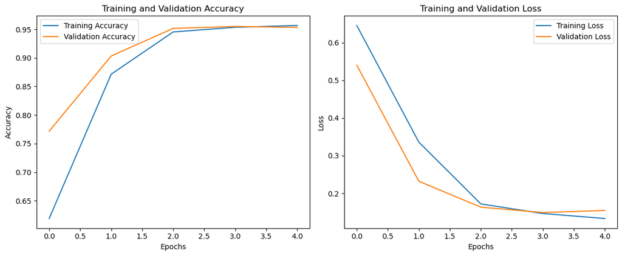

```python
plt.figure(figsize=(12, 5))

# Accuracy
plt.subplot(1, 2, 1)
plt.plot(history.history['accuracy'], label='Training Accuracy')
plt.plot(history.history['val_accuracy'], label='Validation Accuracy')
plt.xlabel('Epochs'); plt.ylabel('Accuracy')
plt.title('Training and Validation Accuracy'); plt.legend()

# Loss
plt.subplot(1, 2, 2)
plt.plot(history.history['loss'], label='Training Loss')
plt.plot(history.history['val_loss'], label='Validation Loss')
plt.xlabel('Epochs'); plt.ylabel('Loss')
plt.title('Training and Validation Loss'); plt.legend()

plt.tight_layout()
plt.show()
```

### Evaluate Confusion Matrix

```
11/19 ━━━━━━━━━━━━━━━━━━━━ 0s 11ms/step
```

[output not shown]

```
19/19 ━━━━━━━━━━━━━━━━━━━━ 0s 13ms/step
```

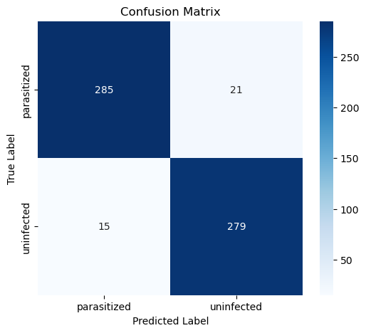

```
Classification Report:
               precision    recall  f1-score   support

 parasitized       0.95      0.93      0.94       306
  uninfected       0.93      0.95      0.94       294

    accuracy                           0.94       600
   macro avg       0.94      0.94      0.94       600
weighted avg       0.94      0.94      0.94       600
```

```python
# Collect true labels and model predictions over the test set (same order).
y_true = np.concatenate([y.numpy() for _, y in test_ds])
y_prob = model.predict(test_ds).ravel()
y_pred = (y_prob > 0.5).astype(int)           # threshold the probability at 0.5

# Confusion matrix
conf_matrix = confusion_matrix(y_true, y_pred)
plt.figure(figsize=(6, 5))
sns.heatmap(conf_matrix, annot=True, fmt='d', cmap='Blues',
            xticklabels=class_names, yticklabels=class_names)
plt.xlabel('Predicted Label'); plt.ylabel('True Label')
plt.title('Confusion Matrix')
plt.show()

# Precision / recall / F1 per class -- in medicine, recall on "parasitized" matters most.
print("\nClassification Report:\n", classification_report(y_true, y_pred, target_names=class_names))
```

## Noising Filters

A **noising filter** is a tool used in image processing and deep learning that alters pixel values in a controlled way (typically by smoothing, blurring, or adding noise) to affect how information is represented in an image. Instead of letting a model focus on the exact value of every individual pixel, a noising filter encourages the model to consider local regions as a whole.

This approach can help:

- **Reduce overfitting:** By obscuring specific pixel-level details, the model learns more robust, general patterns rather than memorizing noise or irrelevant details in the training images.
- **Feature extraction:** Noising filters can help emphasize essential structures like edges and shapes, while de-emphasizing background textures or minor variations.
- **Robustness:** Adding controlled noise or smoothing compels the model to generalize, making it less sensitive to minor input variations and improving performance on new, unseen data.

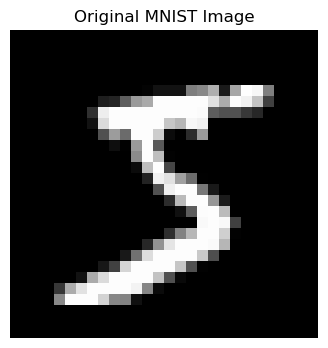

```python
import numpy as np
import matplotlib.pyplot as plt
from keras.datasets import mnist

# Load MNIST dataset
(train_images, train_labels), (test_images, test_labels) = mnist.load_data()

# Select a single image
image = train_images[0]  # First image in the dataset

# Display the original image
plt.figure(figsize=(4,4))
plt.imshow(image, cmap='gray')
plt.title("Original MNIST Image")
plt.axis('off')
plt.show()
```

### Convolution Noising Filter

A **convolution-based noising filter** works by applying a small matrix, known as a kernel, to local regions of an image. As this kernel moves across the image, it combines the values of neighboring pixels according to a mathematical rule, typically an average or a weighted sum. This operation blends pixel values together, which can create a blurring effect that softens fine details and helps suppress random noise.

- **Blurring:** For example, a simple averaging kernel replaces each pixel’s value with the mean of its neighbors, producing a blur.
- **Denoising:** This same approach can smooth out random noise by making the pixel values in a neighborhood more similar to each other.
- **Generalization:** By forcing the model to “see” smoothed patterns instead of crisp pixel-by-pixel detail, convolutional filters help the model learn larger, more meaningful features.

#### Example

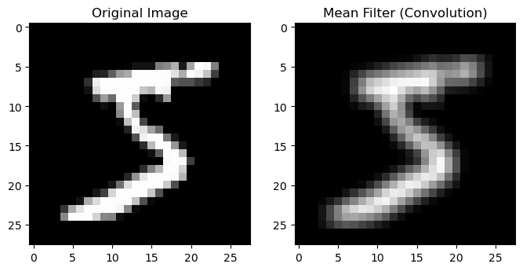

```python
from scipy.ndimage import convolve

# Define a 3x3 mean filter kernel
mean_kernel = np.ones((3,3)) / 9

# Apply convolution filter
mean_filtered_image = convolve(image, mean_kernel, mode='constant', cval=0.0)

# Display results
plt.figure(figsize=(8,4))
plt.subplot(1,2,1), plt.imshow(image, cmap='gray'), plt.title("Original Image")
plt.subplot(1,2,2), plt.imshow(mean_filtered_image, cmap='gray'), plt.title("Mean Filter (Convolution)")
plt.show()
```

### Gaussian Noising Filter

The **Gaussian filter** is a specific type of convolutional filter where the kernel weights are distributed according to a Gaussian (bell-shaped) curve. **In this filter, pixels closer to the center of the kernel have a greater impact on the output than those farther away.** In other words, pixels near the center of the kernel have the most influence, while those further away contribute less. This approach creates a smooth, natural-looking blur that reduces noise while still maintaining edge information better than a simple averaging filter. Gaussian filters are widely used for tasks where it is important to reduce unwanted noise or variation without losing the critical structural features of an image.

#### Example

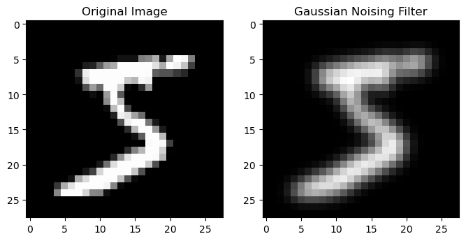

```python
from scipy.ndimage import gaussian_filter

# Apply Gaussian blur with a standard deviation of 1
gaussian_blurred_image = gaussian_filter(image, sigma=1)

# Display results
plt.figure(figsize=(8,4))
plt.subplot(1,2,1), plt.imshow(image, cmap='gray'), plt.title("Original Image")
plt.subplot(1,2,2), plt.imshow(gaussian_blurred_image, cmap='gray'), plt.title("Gaussian Noising Filter")
plt.show()
```

### Vertical Edges Filter

#### Example

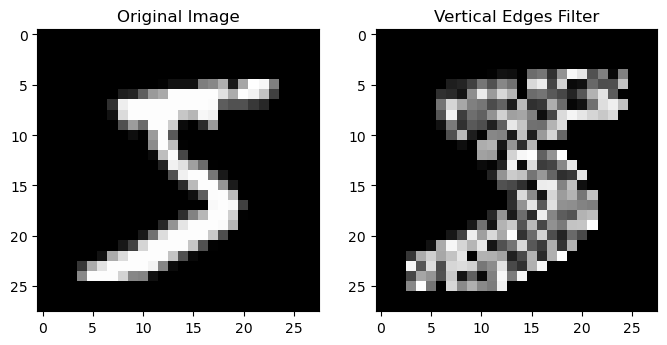

```python
from scipy.ndimage import sobel

# Apply vertical edge detection
vertical_edges = sobel(image, axis=1)

# Display results
plt.figure(figsize=(8,4))
plt.subplot(1,2,1), plt.imshow(image, cmap='gray'), plt.title("Original Image")
plt.subplot(1,2,2), plt.imshow(vertical_edges, cmap='gray'), plt.title("Vertical Edges Filter")
plt.show()
```

### Horizontal Edge Filter

#### Example

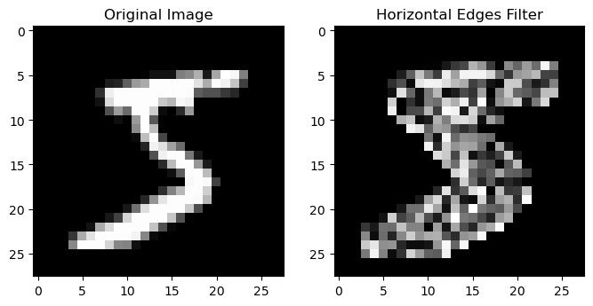

```python
# Apply horizontal edge detection
horizontal_edges = sobel(image, axis=0)

# Display results
plt.figure(figsize=(8,4))
plt.subplot(1,2,1), plt.imshow(image, cmap='gray'), plt.title("Original Image")
plt.subplot(1,2,2), plt.imshow(horizontal_edges, cmap='gray'), plt.title("Horizontal Edges Filter")
plt.show()
```

## Prominent CNN Architectures

Over the years, several **Convolutional Neural Network (CNN) architectures** have been developed, significantly improving the efficiency and accuracy of deep learning models for image classification. These architectures have introduced innovations in convolutional layers, activation functions, and network depth, allowing CNNs to handle increasingly complex tasks.

### LeNet-5 (1998)

**LeNet-5** was one of the earliest CNN architectures. It was developed by Yann LeCun in 1998 for handwritten digit recognition. It consists of two convolutional layers followed by subsampling (pooling) layers, fully connected layers, and a softmax classifier. The architecture was designed to recognize handwritten digits from the MNIST dataset, making it an excellent starting point for understanding CNNs.

**Note:** LeNet-5 uses tanh activation instead of ReLU, as ReLU was not commonly used at the time. The model's average pooling layers reduce feature map size while retaining essential information.

[figure not shown]

```python
import tensorflow as tf
from keras import datasets, layers, models

# Load and preprocess MNIST dataset
(train_images, train_labels), (test_images, test_labels) = datasets.mnist.load_data()
train_images, test_images = train_images / 255.0, test_images / 255.0
train_images = train_images.reshape((train_images.shape[0], 28, 28, 1))
test_images = test_images.reshape((test_images.shape[0], 28, 28, 1))

# Define LeNet-5 model
model = models.Sequential([
    layers.Conv2D(6, (5,5), activation='tanh', input_shape=(28,28,1)),
    layers.AveragePooling2D((2,2)),
    layers.Conv2D(16, (5,5), activation='tanh'),
    layers.AveragePooling2D((2,2)),
    layers.Flatten(),
    layers.Dense(120, activation='tanh'),
    layers.Dense(84, activation='tanh'),
    layers.Dense(10, activation='softmax') # Output layer for 10 classes
])

# Compile and summarize model
model.compile(optimizer='adam', loss='sparse_categorical_crossentropy', metrics=['accuracy'])
model.summary()
```

```
Model: "sequential_1"
```

```
┏━━━━━━━━━━━━━━━━━━━━━━━━━━━━━━━━━┳━━━━━━━━━━━━━━━━━━━━━━━━┳━━━━━━━━━━━━━━━┓
┃ Layer (type)                    ┃ Output Shape           ┃       Param # ┃
┡━━━━━━━━━━━━━━━━━━━━━━━━━━━━━━━━━╇━━━━━━━━━━━━━━━━━━━━━━━━╇━━━━━━━━━━━━━━━┩
│ conv2d_4 (Conv2D)               │ (None, 24, 24, 6)      │           156 │
├─────────────────────────────────┼────────────────────────┼───────────────┤
│ average_pooling2d               │ (None, 12, 12, 6)      │             0 │
│ (AveragePooling2D)              │                        │               │
├─────────────────────────────────┼────────────────────────┼───────────────┤
│ conv2d_5 (Conv2D)               │ (None, 8, 8, 16)       │         2,416 │
├─────────────────────────────────┼────────────────────────┼───────────────┤
│ average_pooling2d_1             │ (None, 4, 4, 16)       │             0 │
│ (AveragePooling2D)              │                        │               │
├─────────────────────────────────┼────────────────────────┼───────────────┤
│ flatten_1 (Flatten)             │ (None, 256)            │             0 │
├─────────────────────────────────┼────────────────────────┼───────────────┤
│ dense_2 (Dense)                 │ (None, 120)            │        30,840 │
├─────────────────────────────────┼────────────────────────┼───────────────┤
│ dense_3 (Dense)                 │ (None, 84)             │        10,164 │
├─────────────────────────────────┼────────────────────────┼───────────────┤
│ dense_4 (Dense)                 │ (None, 10)             │           850 │
└─────────────────────────────────┴────────────────────────┴───────────────┘
```

```
 Total params: 44,426 (173.54 KB)
```

```
 Trainable params: 44,426 (173.54 KB)
```

```
 Non-trainable params: 0 (0.00 B)
```

### AlexNet (2012)

**AlexNet**, developed by Alex Krizhevsky, was the first deep CNN to win the ImageNet competition, significantly outperforming previous methods. It introduced the ReLU activation function, which sped up training, and used dropout to prevent overfitting. It was also notable for using overlapping max pooling and multiple GPUs to train deeper networks.

[figure not shown]

```python
import tensorflow as tf
from keras import datasets, layers, models

# Load and preprocess MNIST dataset
(train_images, train_labels), (test_images, test_labels) = datasets.mnist.load_data()
train_images, test_images = train_images / 255.0, test_images / 255.0
train_images = train_images.reshape((train_images.shape[0], 28, 28, 1))
test_images = test_images.reshape((test_images.shape[0], 28, 28, 1))

# Define a simplified AlexNet for MNIST
model = models.Sequential([
    layers.Conv2D(64, (3,3), activation='relu', padding='same', input_shape=(28,28,1)),
    layers.MaxPooling2D((2,2)),

    layers.Conv2D(128, (3,3), activation='relu', padding='same'),
    layers.MaxPooling2D((2,2)),

    layers.Conv2D(256, (3,3), activation='relu', padding='same'),

    layers.Flatten(),
    layers.Dense(512, activation='relu'),
    layers.Dropout(0.5),
    layers.Dense(10, activation='softmax')  # Output layer for 10 classes
])

# Compile and summarize model
model.compile(optimizer='adam', loss='sparse_categorical_crossentropy', metrics=['accuracy'])
model.summary()
```

```
Model: "sequential_4"
```

```
┏━━━━━━━━━━━━━━━━━━━━━━━━━━━━━━━━━┳━━━━━━━━━━━━━━━━━━━━━━━━┳━━━━━━━━━━━━━━━┓
┃ Layer (type)                    ┃ Output Shape           ┃       Param # ┃
┡━━━━━━━━━━━━━━━━━━━━━━━━━━━━━━━━━╇━━━━━━━━━━━━━━━━━━━━━━━━╇━━━━━━━━━━━━━━━┩
│ conv2d_20 (Conv2D)              │ (None, 28, 28, 64)     │           640 │
├─────────────────────────────────┼────────────────────────┼───────────────┤
│ max_pooling2d_8 (MaxPooling2D)  │ (None, 14, 14, 64)     │             0 │
├─────────────────────────────────┼────────────────────────┼───────────────┤
│ conv2d_21 (Conv2D)              │ (None, 14, 14, 128)    │        73,856 │
├─────────────────────────────────┼────────────────────────┼───────────────┤
│ max_pooling2d_9 (MaxPooling2D)  │ (None, 7, 7, 128)      │             0 │
├─────────────────────────────────┼────────────────────────┼───────────────┤
│ conv2d_22 (Conv2D)              │ (None, 7, 7, 256)      │       295,168 │
├─────────────────────────────────┼────────────────────────┼───────────────┤
│ flatten_4 (Flatten)             │ (None, 12544)          │             0 │
├─────────────────────────────────┼────────────────────────┼───────────────┤
│ dense_10 (Dense)                │ (None, 512)            │     6,423,040 │
├─────────────────────────────────┼────────────────────────┼───────────────┤
│ dropout_2 (Dropout)             │ (None, 512)            │             0 │
├─────────────────────────────────┼────────────────────────┼───────────────┤
│ dense_11 (Dense)                │ (None, 10)             │         5,130 │
└─────────────────────────────────┴────────────────────────┴───────────────┘
```

```
 Total params: 6,797,834 (25.93 MB)
```

```
 Trainable params: 6,797,834 (25.93 MB)
```

```
 Non-trainable params: 0 (0.00 B)
```

### VGG-16 and VGG-19 (2014)

The VGG architectures, developed by the Visual Geometry Group at Oxford, introduced the idea of using small $ 3×3 $ filters with deep networks. The small filter size allowed the network to capture fine details while reducing the number of parameters compared to larger filters. VGG-16 and VGG-19 are deeper networks with 16 and 19 weight layers, respectively. VGG models rely on stacked small convolutional filters followed by max pooling, allowing deeper feature extraction while controlling model complexity.

[figure not shown]

```python
# Define a simplified VGG-16 model for MNIST
model = models.Sequential([
    layers.Conv2D(64, (3,3), activation='relu', padding='same', input_shape=(28,28,1)),
    layers.Conv2D(64, (3,3), activation='relu', padding='same'),
    layers.MaxPooling2D((2,2)),

    layers.Conv2D(128, (3,3), activation='relu', padding='same'),
    layers.Conv2D(128, (3,3), activation='relu', padding='same'),
    layers.MaxPooling2D((2,2)),

    layers.Flatten(),
    layers.Dense(256, activation='relu'),
    layers.Dense(10, activation='softmax')
])

# Compile and summarize model
model.compile(optimizer='adam', loss='sparse_categorical_crossentropy', metrics=['accuracy'])
model.summary()
```

```
Model: "sequential_3"
```

```
┏━━━━━━━━━━━━━━━━━━━━━━━━━━━━━━━━━┳━━━━━━━━━━━━━━━━━━━━━━━━┳━━━━━━━━━━━━━━━┓
┃ Layer (type)                    ┃ Output Shape           ┃       Param # ┃
┡━━━━━━━━━━━━━━━━━━━━━━━━━━━━━━━━━╇━━━━━━━━━━━━━━━━━━━━━━━━╇━━━━━━━━━━━━━━━┩
│ conv2d_11 (Conv2D)              │ (None, 28, 28, 64)     │           640 │
├─────────────────────────────────┼────────────────────────┼───────────────┤
│ conv2d_12 (Conv2D)              │ (None, 28, 28, 64)     │        36,928 │
├─────────────────────────────────┼────────────────────────┼───────────────┤
│ max_pooling2d_5 (MaxPooling2D)  │ (None, 14, 14, 64)     │             0 │
├─────────────────────────────────┼────────────────────────┼───────────────┤
│ conv2d_13 (Conv2D)              │ (None, 14, 14, 128)    │        73,856 │
├─────────────────────────────────┼────────────────────────┼───────────────┤
│ conv2d_14 (Conv2D)              │ (None, 14, 14, 128)    │       147,584 │
├─────────────────────────────────┼────────────────────────┼───────────────┤
│ max_pooling2d_6 (MaxPooling2D)  │ (None, 7, 7, 128)      │             0 │
├─────────────────────────────────┼────────────────────────┼───────────────┤
│ flatten_3 (Flatten)             │ (None, 6272)           │             0 │
├─────────────────────────────────┼────────────────────────┼───────────────┤
│ dense_8 (Dense)                 │ (None, 256)            │     1,605,888 │
├─────────────────────────────────┼────────────────────────┼───────────────┤
│ dense_9 (Dense)                 │ (None, 10)             │         2,570 │
└─────────────────────────────────┴────────────────────────┴───────────────┘
```

```
 Total params: 1,867,466 (7.12 MB)
```

```
 Trainable params: 1,867,466 (7.12 MB)
```

```
 Non-trainable params: 0 (0.00 B)
```

### ResNet (2015)

**ResNet**, or Residual Networks, introduced skip connections (residual connections) to address the vanishing gradient problem in deep networks. These connections allow gradients to flow directly through the network, making it easier to train very deep models. By implementing residual connections, the model can learn identity mappings, preventing degradation in accuracy as the depth increases.

[figure not shown]

```python
import tensorflow as tf
from keras.layers import Add, Conv2D, Input, Flatten, Dense, MaxPooling2D, ReLU, BatchNormalization
from keras.models import Model

# Residual block function with identity mapping fix
def residual_block(x, filters, downsample=False):
    res = Conv2D(filters, (3,3), padding='same', activation='relu')(x)
    res = Conv2D(filters, (3,3), padding='same')(res)

    # Adjust dimensions using a 1x1 convolution if downsampling or filter size changes
    if downsample or x.shape[-1] != filters:
        x = Conv2D(filters, (1,1), padding='same')(x)

    res = Add()([x, res])  # Skip connection
    return ReLU()(res)

# Define ResNet-like model for MNIST
inputs = Input(shape=(28,28,1))
x = Conv2D(64, (3,3), activation='relu', padding='same')(inputs)
x = residual_block(x, 64)  # First residual block
x = MaxPooling2D((2,2))(x)

x = residual_block(x, 128, downsample=True)  # Second residual block with dimension matching
x = MaxPooling2D((2,2))(x)

x = Flatten()(x)
x = Dense(128, activation='relu')(x)
outputs = Dense(10, activation='softmax')(x)

model = Model(inputs, outputs)

# Compile and summarize model
model.compile(optimizer='adam', loss='sparse_categorical_crossentropy', metrics=['accuracy'])
model.summary()
```

```
Model: "functional_4"
```

```
┏━━━━━━━━━━━━━━━━━━━━━┳━━━━━━━━━━━━━━━━━━━┳━━━━━━━━━━━━┳━━━━━━━━━━━━━━━━━━━┓
┃ Layer (type)        ┃ Output Shape      ┃    Param # ┃ Connected to      ┃
┡━━━━━━━━━━━━━━━━━━━━━╇━━━━━━━━━━━━━━━━━━━╇━━━━━━━━━━━━╇━━━━━━━━━━━━━━━━━━━┩
│ input_layer_6       │ (None, 28, 28, 1) │          0 │ -                 │
│ (InputLayer)        │                   │            │                   │
├─────────────────────┼───────────────────┼────────────┼───────────────────┤
│ conv2d_23 (Conv2D)  │ (None, 28, 28,    │        640 │ input_layer_6[0]… │
│                     │ 64)               │            │                   │
├─────────────────────┼───────────────────┼────────────┼───────────────────┤
│ conv2d_24 (Conv2D)  │ (None, 28, 28,    │     36,928 │ conv2d_23[0][0]   │
│                     │ 64)               │            │                   │
├─────────────────────┼───────────────────┼────────────┼───────────────────┤
│ conv2d_25 (Conv2D)  │ (None, 28, 28,    │     36,928 │ conv2d_24[0][0]   │
│                     │ 64)               │            │                   │
├─────────────────────┼───────────────────┼────────────┼───────────────────┤
│ add_2 (Add)         │ (None, 28, 28,    │          0 │ conv2d_23[0][0],  │
│                     │ 64)               │            │ conv2d_25[0][0]   │
├─────────────────────┼───────────────────┼────────────┼───────────────────┤
│ re_lu_1 (ReLU)      │ (None, 28, 28,    │          0 │ add_2[0][0]       │
│                     │ 64)               │            │                   │
├─────────────────────┼───────────────────┼────────────┼───────────────────┤
│ max_pooling2d_10    │ (None, 14, 14,    │          0 │ re_lu_1[0][0]     │
│ (MaxPooling2D)      │ 64)               │            │                   │
├─────────────────────┼───────────────────┼────────────┼───────────────────┤
│ conv2d_26 (Conv2D)  │ (None, 14, 14,    │     73,856 │ max_pooling2d_10… │
│                     │ 128)              │            │                   │
├─────────────────────┼───────────────────┼────────────┼───────────────────┤
│ conv2d_28 (Conv2D)  │ (None, 14, 14,    │      8,320 │ max_pooling2d_10… │
│                     │ 128)              │            │                   │
├─────────────────────┼───────────────────┼────────────┼───────────────────┤
│ conv2d_27 (Conv2D)  │ (None, 14, 14,    │    147,584 │ conv2d_26[0][0]   │
│                     │ 128)              │            │                   │
├─────────────────────┼───────────────────┼────────────┼───────────────────┤
│ add_3 (Add)         │ (None, 14, 14,    │          0 │ conv2d_28[0][0],  │
│                     │ 128)              │            │ conv2d_27[0][0]   │
├─────────────────────┼───────────────────┼────────────┼───────────────────┤
│ re_lu_2 (ReLU)      │ (None, 14, 14,    │          0 │ add_3[0][0]       │
│                     │ 128)              │            │                   │
├─────────────────────┼───────────────────┼────────────┼───────────────────┤
│ max_pooling2d_11    │ (None, 7, 7, 128) │          0 │ re_lu_2[0][0]     │
│ (MaxPooling2D)      │                   │            │                   │
├─────────────────────┼───────────────────┼────────────┼───────────────────┤
│ flatten_5 (Flatten) │ (None, 6272)      │          0 │ max_pooling2d_11… │
├─────────────────────┼───────────────────┼────────────┼───────────────────┤
│ dense_12 (Dense)    │ (None, 128)       │    802,944 │ flatten_5[0][0]   │
├─────────────────────┼───────────────────┼────────────┼───────────────────┤
│ dense_13 (Dense)    │ (None, 10)        │      1,290 │ dense_12[0][0]    │
└─────────────────────┴───────────────────┴────────────┴───────────────────┘
```

```
 Total params: 1,108,490 (4.23 MB)
```

```
 Trainable params: 1,108,490 (4.23 MB)
```

```
 Non-trainable params: 0 (0.00 B)
```

### EfficientNet (2019)

**EfficientNet**, developed by Google, introduced a compound scaling method that balances network depth, width, and resolution. It provides better accuracy with fewer parameters by using a principled approach to scaling CNN architectures. EfficientNet scales CNNs optimally by expanding depth, width, and input resolution proportionally, achieving high accuracy with fewer computational resources.

EfficientNet is a pretrained model available in TensorFlow.

[figure not shown]

```python
import tensorflow as tf
from keras.applications import EfficientNetB0
from keras import layers, models
import keras.datasets.mnist as mnist
import numpy as np
import keras.backend as K

# Load and preprocess MNIST dataset
(train_images, train_labels), (test_images, test_labels) = mnist.load_data()

# Resize MNIST images from 28x28 to 32x32 and convert grayscale to RGB (3 channels)
train_images = tf.image.resize_with_pad(train_images[..., np.newaxis], 32, 32)
test_images = tf.image.resize_with_pad(test_images[..., np.newaxis], 32, 32)

train_images = tf.image.grayscale_to_rgb(train_images)  # Convert grayscale to RGB
test_images = tf.image.grayscale_to_rgb(test_images)  # Convert grayscale to RGB

train_images, test_images = train_images / 255.0, test_images / 255.0  # Normalize pixel values

# Load EfficientNetB0 with adjusted input shape
base_model = EfficientNetB0(weights=None, input_shape=(32,32,3), classes=10)

# Compile and summarize the model
base_model.compile(optimizer='adam', loss='sparse_categorical_crossentropy', metrics=['accuracy'])
base_model.summary()
```

```
Model: "efficientnetb0"
```

```
┏━━━━━━━━━━━━━━━━━━━━━┳━━━━━━━━━━━━━━━━━━━┳━━━━━━━━━━━━┳━━━━━━━━━━━━━━━━━━━┓
┃ Layer (type)        ┃ Output Shape      ┃    Param # ┃ Connected to      ┃
┡━━━━━━━━━━━━━━━━━━━━━╇━━━━━━━━━━━━━━━━━━━╇━━━━━━━━━━━━╇━━━━━━━━━━━━━━━━━━━┩
│ input_layer_7       │ (None, 32, 32, 3) │          0 │ -                 │
│ (InputLayer)        │                   │            │                   │
├─────────────────────┼───────────────────┼────────────┼───────────────────┤
│ rescaling           │ (None, 32, 32, 3) │          0 │ input_layer_7[0]… │
│ (Rescaling)         │                   │            │                   │
├─────────────────────┼───────────────────┼────────────┼───────────────────┤
│ normalization       │ (None, 32, 32, 3) │          7 │ rescaling[0][0]   │
│ (Normalization)     │                   │            │                   │
├─────────────────────┼───────────────────┼────────────┼───────────────────┤
│ stem_conv_pad       │ (None, 33, 33, 3) │          0 │ normalization[0]… │
│ (ZeroPadding2D)     │                   │            │                   │
├─────────────────────┼───────────────────┼────────────┼───────────────────┤
│ stem_conv (Conv2D)  │ (None, 16, 16,    │        864 │ stem_conv_pad[0]… │
│                     │ 32)               │            │                   │
├─────────────────────┼───────────────────┼────────────┼───────────────────┤
│ stem_bn             │ (None, 16, 16,    │        128 │ stem_conv[0][0]   │
│ (BatchNormalizatio… │ 32)               │            │                   │
├─────────────────────┼───────────────────┼────────────┼───────────────────┤
│ stem_activation     │ (None, 16, 16,    │          0 │ stem_bn[0][0]     │
│ (Activation)        │ 32)               │            │                   │
├─────────────────────┼───────────────────┼────────────┼───────────────────┤
│ block1a_dwconv      │ (None, 16, 16,    │        288 │ stem_activation[… │
│ (DepthwiseConv2D)   │ 32)               │            │                   │
├─────────────────────┼───────────────────┼────────────┼───────────────────┤
│ block1a_bn          │ (None, 16, 16,    │        128 │ block1a_dwconv[0… │
│ (BatchNormalizatio… │ 32)               │            │                   │
├─────────────────────┼───────────────────┼────────────┼───────────────────┤
│ block1a_activation  │ (None, 16, 16,    │          0 │ block1a_bn[0][0]  │
│ (Activation)        │ 32)               │            │                   │
├─────────────────────┼───────────────────┼────────────┼───────────────────┤
│ block1a_se_squeeze  │ (None, 32)        │          0 │ block1a_activati… │
│ (GlobalAveragePool… │                   │            │                   │
├─────────────────────┼───────────────────┼────────────┼───────────────────┤
│ block1a_se_reshape  │ (None, 1, 1, 32)  │          0 │ block1a_se_squee… │
│ (Reshape)           │                   │            │                   │
├─────────────────────┼───────────────────┼────────────┼───────────────────┤
│ block1a_se_reduce   │ (None, 1, 1, 8)   │        264 │ block1a_se_resha… │
```

[output cut: 667 more lines]

```
├─────────────────────┼───────────────────┼────────────┼───────────────────┤
│ top_bn              │ (None, 1, 1,      │      5,120 │ top_conv[0][0]    │
│ (BatchNormalizatio… │ 1280)             │            │                   │
├─────────────────────┼───────────────────┼────────────┼───────────────────┤
│ top_activation      │ (None, 1, 1,      │          0 │ top_bn[0][0]      │
│ (Activation)        │ 1280)             │            │                   │
├─────────────────────┼───────────────────┼────────────┼───────────────────┤
│ avg_pool            │ (None, 1280)      │          0 │ top_activation[0… │
│ (GlobalAveragePool… │                   │            │                   │
├─────────────────────┼───────────────────┼────────────┼───────────────────┤
│ top_dropout         │ (None, 1280)      │          0 │ avg_pool[0][0]    │
│ (Dropout)           │                   │            │                   │
├─────────────────────┼───────────────────┼────────────┼───────────────────┤
│ predictions (Dense) │ (None, 10)        │     12,810 │ top_dropout[0][0] │
└─────────────────────┴───────────────────┴────────────┴───────────────────┘
```

```
 Total params: 4,062,381 (15.50 MB)
```

```
 Trainable params: 4,020,358 (15.34 MB)
```

```
 Non-trainable params: 42,023 (164.16 KB)
```

## Conclusion

In this notebook we built a Convolutional Neural Network from the ground up. We started with the single operation at the heart of it all — the **convolution**, a small kernel sliding across an image and summing local products into a **feature map** — and watched, number by number, how different kernels pick out vertical edges, horizontal edges, or a blur. From there we stacked the pieces: **stride and padding** to control output size, a **ReLU activation** to add non-linearity, **pooling** to shrink feature maps while keeping the strongest signals, and finally **flatten → dense → softmax** to turn learned features into class probabilities.

We then assembled those pieces into complete models and trained them twice: once on the clean Fashion-MNIST benchmark, and once on a messy, **real-world medical dataset** (malaria blood-smear cells) — the same tools, with real stakes. Along the way we saw that convolution doubles as a classic image-processing tool (blur, Gaussian, and edge filters), and that the famous architectures (**LeNet → AlexNet → VGG → ResNet → EfficientNet**) are really just deeper, smarter arrangements of these same building blocks.

The big takeaway: **CNNs learn a hierarchy of features.** Early layers detect edges and textures; deeper layers combine them into shapes, parts, and eventually whole objects — all learned from data, with no hand-designed features required.

### Additional Resources

**Interactive & intuition**

- [CNN Explainer](https://poloclub.github.io/cnn-explainer/) — watch an image flow through a real CNN, layer by layer.
- [Image Kernels, explained visually](https://setosa.io/ev/image-kernels/) — drag kernels over an image; a perfect companion to our hand-set-kernel examples.
- [TensorFlow Playground](https://playground.tensorflow.org/) — build and train a small network in the browser and see it learn.
- [3Blue1Brown — But what is a convolution?](https://www.3blue1brown.com/lessons/convolutions) — beautiful visual intuition for the convolution operation.

**Go deeper**

- [Stanford CS231n — Convolutional Networks notes](https://cs231n.github.io/convolutional-networks/) — the canonical, thorough write-up of CNN mechanics.
- [Keras — Image classification from scratch](https://keras.io/examples/vision/image_classification_from_scratch/) — an end-to-end TF/Keras example to adapt to your own images.
- [PyTorch — Training a classifier](https://pytorch.org/tutorials/beginner/blitz/cifar10_tutorial.html) — the equivalent hands-on tutorial in PyTorch.